# Caracterización de hogares beneficiarios IMV frente a potenciales no beneficiarios

# Introducción

Este ejercicio tiene como objetivo mostrar las diferencias socioeconómicas de los hogares beneficiarios y potenciales no beneficiarios del IMV, lo que podría arrojar luz sobre el non-takeup y ayudar a mejorar el targeting de esta política pública.

Para ello, se utilizan todos los hogares potenciales o beneficiarios de España (ficheros AEAT 2023), filtrando aquellos hogares sin adultos, con más de 10 adultos, con menos de 700€ de renta anual, o con residencia en el País Vasco/Navarra. Con estos datos, se estiman un modelo probabilístico y los efectos marginales promedios de cada variable. Finalmente, se muestran diferentes medidas de evaluación del modelo.

Las variables explicativas a nivel de hogar utilizadas son:

- Variable binaria que indica si hay algún extranjero en el hogar
- Variable binaria que indica si hay alguna persona con discapacidad en el hogar
- Variable binaria que indica si la vivienda habitual se encuentra en propiedad
- Variable de tipo de hogar dividida en unipersonal, monoparental, adultos sin hijos, y adultos con hijos
- Comunidad Autónoma de residencia
- Renta del hogar equivalente pre imv.

# Limpieza

**Mostrar código**

```r
vars_modelo <- c("benef","pobmil","pobmil_2","tasa_paro","renta_mediana", "renta_hogar_eq",
                 "capital","extranjero","minus","propietario","tipo_hogar","ccaa")

dfmodelo <- dfmodelo[complete.cases(dfmodelo[, ..vars_modelo])]

dfmodelo$renta_hogar_eq<-dfmodelo$renta_hogar_eq/1000
```

# Contextualización

**Mostrar código**

```r
tasa<-round(nrow(dfmodelo[benef==1])/nrow(dfmodelo)
            ,4)

cat("N =", nrow(dfmodelo),
    "\nNo beneficiarios IMV =", nrow(dfmodelo[benef==0]),
    "\nBeneficiarios IMV =", nrow(dfmodelo[benef==1]),
    "\nP[Y=1] =", tasa
    )
```

```
N = 971734
No beneficiarios IMV = 582771
Beneficiarios IMV = 388963
P[Y=1] = 0.4003
```

# Modelo

**Mostrar código**

```r
formula<-as.formula(paste(vars_modelo[1], "~", paste(vars_modelo[-1], collapse = " + ")))

logit_modelo <- glm(
  formula = formula,
  data = dfmodelo,
  family = binomial
)
```

## Average Marginal Effects

### Gráfico y tabla de coeficientes (sin CCAA)

**Mostrar código**

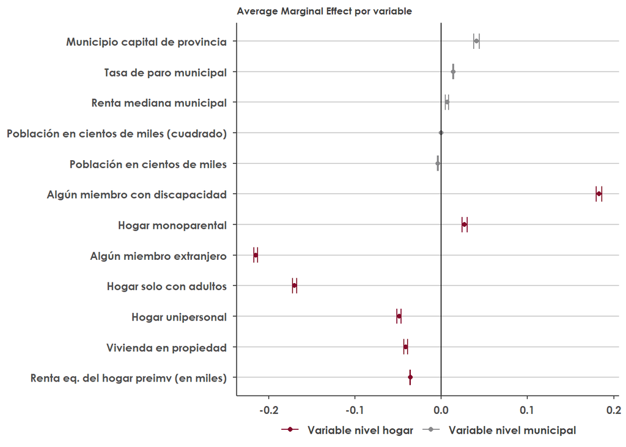

```r
set.seed(1)

muestra <- dfmodelo[sample(.N, 150000)]

m <- margins(logit_modelo, data = muestra)
s <- summary(m)

dfme<-data.table(
  variable = s$factor,
  AME = s$AME,
  SE = s$SE,
  lower=s$lower,
  upper=s$upper,
  n = n,
  p=s$p,
  stars= case_when(s$p<0.1 & s$p >0.05 ~ "*",
                   s$p<0.05 & s$p >0.01 ~ "**",
                   s$p < 0.01 ~ "***")
) %>%
  filter(!startsWith(variable,"ccaa")) %>%
  mutate(nivel= ifelse(variable %in% c("capital", "pobmil", "pobmil_2", "renta_mediana", "tasa_paro"), "Variable nivel municipal", "Variable nivel hogar")) %>%
  arrange(nivel, AME) %>%
  mutate(
         variable= ifelse(variable == "pobmil", "Población en cientos de miles",
                          ifelse(variable=="pobmil_2", "Población en cientos de miles (cuadrado)", variable)),
         variable = case_when(
    variable == "extranjero" ~ "Algún miembro extranjero",
    variable == "minus" ~ "Algún miembro con discapacidad",
    variable == "propietario" ~ "Vivienda en propiedad",
    variable == "renta_hogar_eq" ~ "Renta eq. del hogar preimv (en miles)",
    variable == "tipo_hogarMonoparental" ~ "Hogar monoparental",
    variable == "tipo_hogarSólo adultos" ~ "Hogar solo con adultos",
    variable == "tipo_hogarUnipersonal" ~ "Hogar unipersonal",
    variable == "capital" ~ "Municipio capital de provincia",
    variable == "pobmil" ~ "Población en cientos de miles",
    variable == "pobmil_2" ~ "Población en cientos de miles (cuadrado)",
    variable == "renta_mediana" ~ "Renta mediana municipal",
    variable == "tasa_paro" ~ "Tasa de paro municipal",
    TRUE ~ variable
  ))


p <- dfme %>%
  mutate(orden=paste0(nivel, AME)) %>%
  ggplot(aes(AME, fct_reorder(variable, orden), color=nivel)) +
  geom_point() +
  geom_errorbar(aes(xmin = lower, xmax=upper),width = .5)+
  labs(title = "Average Marginal Effect por variable"
  )+
  geom_vline(xintercept=0)+
  scale_color_manual(values=paleta2)

p
```

**Mostrar código**

```r
dfm1<-dfme %>% mutate(
    `AME (SE)` = sprintf("%.4f%s (%.4f)", AME, stars,SE),
    `IC 95%` = sprintf("[%.4f, %.4f]", lower, upper)
  ) %>%
  arrange(nivel)



kable(
  dfm1%>%
  select(variable, nivel, `AME (SE)`, `IC 95%`, p),
  caption = "Average Marginal Effects del modelo logit",
  digits = 4,
  align = c("l", "l", "c", "c", "c")
) %>%
  kable_styling(full_width = FALSE)
```

Average Marginal Effects del modelo logit

| variable | nivel | AME (SE) | IC 95% | p |
| --- | --- | --- | --- | --- |
| Algún miembro extranjero | Variable nivel hogar | -0.2151*** (0.0011) | [-0.2172, -0.2130] | 0 |
| Hogar solo con adultos | Variable nivel hogar | -0.1701*** (0.0013) | [-0.1726, -0.1675] | 0 |
| Hogar unipersonal | Variable nivel hogar | -0.0489*** (0.0013) | [-0.0513, -0.0464] | 0 |
| Vivienda en propiedad | Variable nivel hogar | -0.0412*** (0.0011) | [-0.0434, -0.0390] | 0 |
| Renta eq. del hogar preimv (en miles) | Variable nivel hogar | -0.0359*** (0.0002) | [-0.0362, -0.0356] | 0 |
| Hogar monoparental | Variable nivel hogar | 0.0271*** (0.0016) | [0.0240, 0.0301] | 0 |
| Algún miembro con discapacidad | Variable nivel hogar | 0.1828*** (0.0016) | [0.1796, 0.1859] | 0 |
| Población en cientos de miles | Variable nivel municipal | -0.0040*** (0.0004) | [-0.0047, -0.0032] | 0 |
| Población en cientos de miles (cuadrado) | Variable nivel municipal | 0.0001*** (0.0000) | [0.0001, 0.0001] | 0 |
| Renta mediana municipal | Variable nivel municipal | 0.0068*** (0.0010) | [0.0048, 0.0087] | 0 |
| Tasa de paro municipal | Variable nivel municipal | 0.0139*** (0.0002) | [0.0135, 0.0143] | 0 |
| Municipio capital de provincia | Variable nivel municipal | 0.0409*** (0.0017) | [0.0376, 0.0441] | 0 |

### Mapa coeficientes CCAA

**Mostrar código**

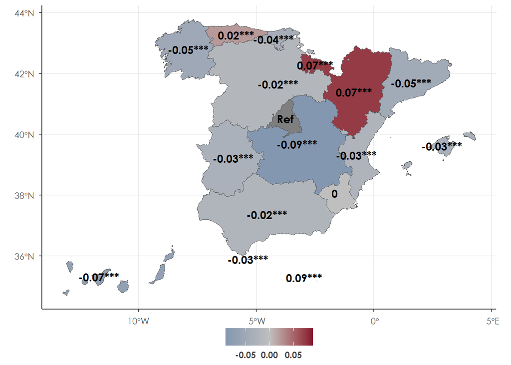

```r
dfmapa<-data.table(
  variable = s$factor,
  codauto= substr(s$factor, 5,6),
  AME = s$AME,
  SE = s$SE,
  lower=s$lower,
  upper=s$upper,
  p=s$p,
  stars= case_when(s$p<0.1 & s$p >0.05 ~ "*",
                   s$p<0.05 & s$p >0.01 ~ "**",
                   s$p < 0.01 ~ "***",
                   TRUE~ "")
) %>%
  filter(startsWith(variable,"ccaa"))

dfmapa<-left_join(mapSpain::esp_get_ccaa(), dfmapa, by="codauto")

dfmapa %>%
  filter(codauto!= 15, codauto!=16) %>%
  mutate(label=ifelse(codauto==13, "Ref", paste0(round(AME,2), stars))) %>%
  ggplot(aes(fill=AME))+
  geom_sf()+
  geom_sf_text(aes(label=label), color="black")+
  scale_fill_gradient2(low= azul_claro_airef, mid = gris_claro_airef,  high = burgundy_airef)
```

### El caso de la población municipal

Ya que se incluye tanto la población municipal como su transformación cuadrática, el coeficiente real depende del nivel, y por tanto se muestra por separado en el siguiente gráfico.

**Mostrar código**

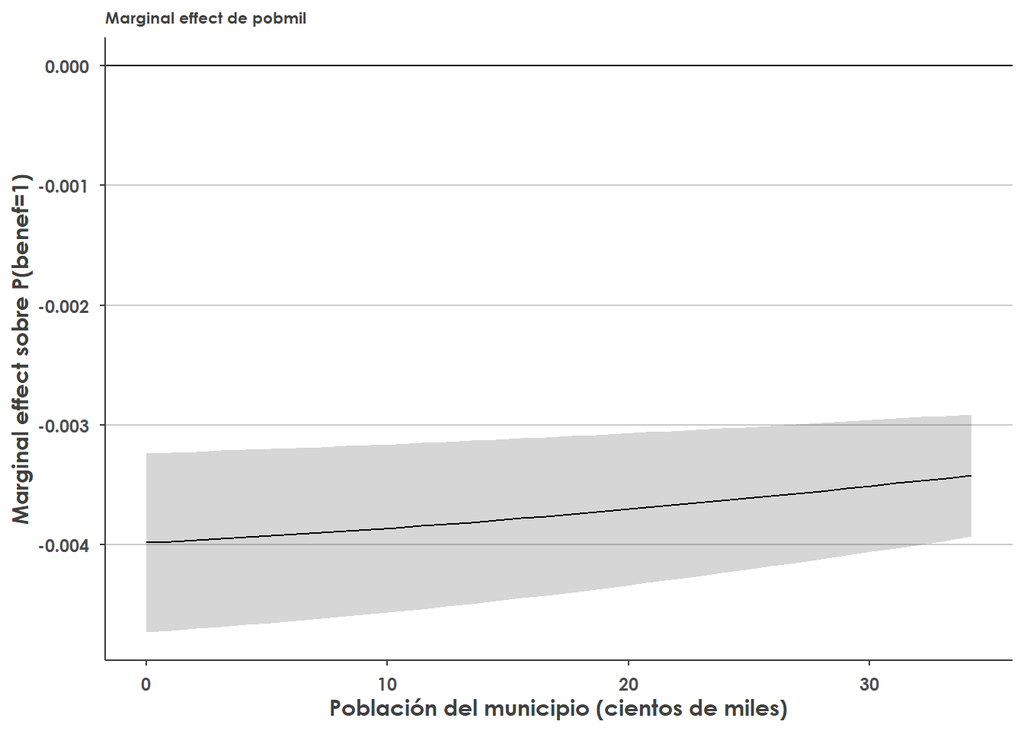

```r
# -------------------------------
# Marginal effect de pobmil (slope)
# -------------------------------
set.seed(1)

muestra <- dfmodelo[sample(.N, 30000)]

grid_pob <- seq(
  min(muestra$pobmil),
  max(muestra$pobmil),
  length.out = round(max(muestra$pobmil))
)

m_slope <- margins(
  logit_modelo,
  variables = "pobmil",
  data=muestra,
  at = list(pobmil = grid_pob)
)

s_slope <- summary(m_slope)

df_slope <- data.table(
  pobmil = grid_pob,
  slope = s_slope$AME,
  lower = s_slope$lower,
  upper = s_slope$upper
)

# Plot
p_slope <- df_slope %>%
  ggplot(aes(pobmil, slope)) +
  geom_line() +
  geom_ribbon(aes(ymin = lower, ymax = upper), alpha = 0.2) +
  geom_hline(yintercept = 0) +
  labs(
    x = "Población del municipio (cientos de miles)",
    y = "Marginal effect sobre P(benef=1)",
    title = "Marginal effect de pobmil"
  )+
  theme(axis.title = element_text())

p_slope
```

# Evaluación del modelo

La evaluación del modelo se basa en diferentes métricas comúnmente utilizadas en la literatura sobre modelos predictivos.

**Mostrar código**

```r
dfmodelo[, prob_pred := predict(logit_modelo, type="response")]
```

## ROC + AUC

**Mostrar código**

```r
roc_obj <- roc(dfmodelo$benef, dfmodelo$prob_pred)
```

**Mostrar código**

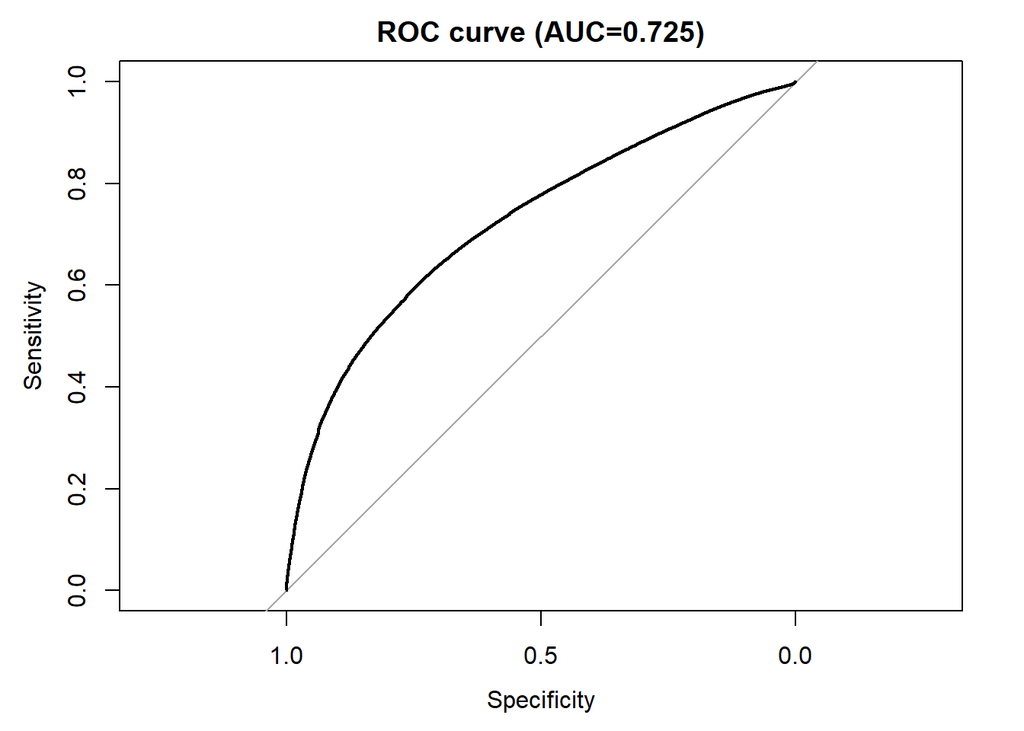

```r
auc_val <- auc(roc_obj)

best_thr <- as.numeric(coords(roc_obj, "best", ret="threshold"))

plot(roc_obj,
     main=paste0("ROC curve (AUC=",round(auc_val,3),")"))
```

## Precision Recall Curve

La curva Precision-Recall muestra el valor del Recall (abscisas) y Precision (ordenadas) para diferentes valores del umbral que determina si una observación es predicha como positivo o negativo.

- El recall es la ratio de beneficiarios reales predichos correctamente
- La precision es la ratio de aciertos sobre el total de observaciones predichas como positive.

Cuando el umbral es bajo, se predicen más positivos, y por tanto el recall aumenta, pero disminuye la precisión.

Un buen modelo es aquel cuya precisión se posiciona ampliamente por encima de la ratio de beneficiarios reales en el dataset (línea discontinua), pues esta marca la precisión si simplemente se predijeran todos los valores como positivos.

**Mostrar código**

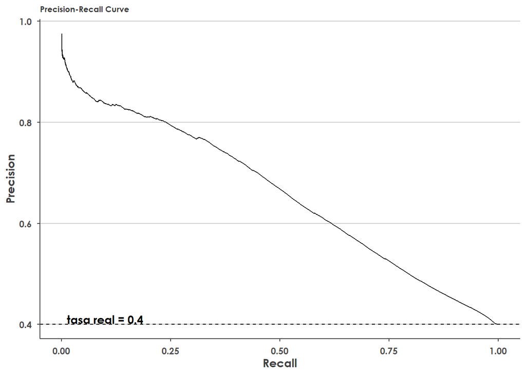

```r
pr_obj <- pr.curve(
  scores.class0 = dfmodelo$prob_pred[dfmodelo$benef==1],
  scores.class1 = dfmodelo$prob_pred[dfmodelo$benef==0],
  curve = TRUE
)

p<-data.frame(x=pr_obj$curve[,1],
           y=pr_obj$curve[,2]) %>%
  filter(x>0.0005) %>%
  ggplot(aes(x,y))+
  geom_line()+
  ggtitle("Precision-Recall Curve")+
  geom_hline(yintercept = mean(dfmodelo$benef), linetype="dashed")+
  annotate(geom = "text", x=.1, y= tasa+.01, label=paste0("tasa real = ",round(tasa,3)), color="black")+
  theme(axis.title = element_text())+
  labs(y="Precision", x="Recall")

p
```

## Calibration plot

El calibration plot mide la fiabilidad de las predicciones del modelo. Marca la tasa real de positivos (ordenadas) para cada nivel de probabilidad predicha (ordenadas). Por ejemplo, el punto de abscisas 0.1 incluye las observaciones para las cuales el modelo predice que existe un 10% de probabilidad de pertenecer al grupo de beneficiarios, e idealmente debería corresponderse con una tasa real del 10%.

La diagonal indica la calibración perfecta, y el modelo se ajusta bien a esta. En caso de no ajustarse a la línea exactamente, se suele preferir que la sobrepase por encima, puesto significa que el modelo infraestima las probabilidades en vez de sobreestimarse.

**Mostrar código**

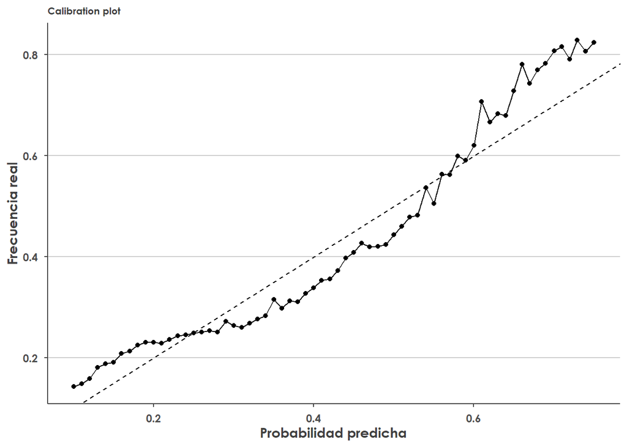

```r
dfmodelo[, bin := round(prob_pred, 2)]

calibration <- dfmodelo[
  , .(
    pred_mean = mean(prob_pred),
    real_rate = mean(benef)
  ),
  by=bin
][order(bin)][pred_mean<=quantile(dfmodelo$prob_pred,probs =.975 ) & pred_mean>=quantile(dfmodelo$prob_pred,probs =.025 ) ]

p1<-calibration %>%
  ggplot(aes(pred_mean, real_rate)) +
  geom_point() +
  geom_line() +
  geom_abline(slope=1, intercept=0, linetype="dashed") +
  labs(
    x="Probabilidad predicha",
    y="Frecuencia real",
    title="Calibration plot"
  )+
  theme(axis.title = element_text())
p1
```

## Gain & Lift Curve

### Gain

La curva gain muestra en el eje de abscisas el acumulativo de la población con mayor probabilidad de ser beneficiario, mientras que en el eje de ordenadas muestra el porcentaje real de beneficiarios incluidos en ese grupo. Ejemplo: “El 50% de la población con mayor probabilidad estimada de ser beneficiario incluye alrededor del 70% de los beneficiarios”.

**Mostrar código**

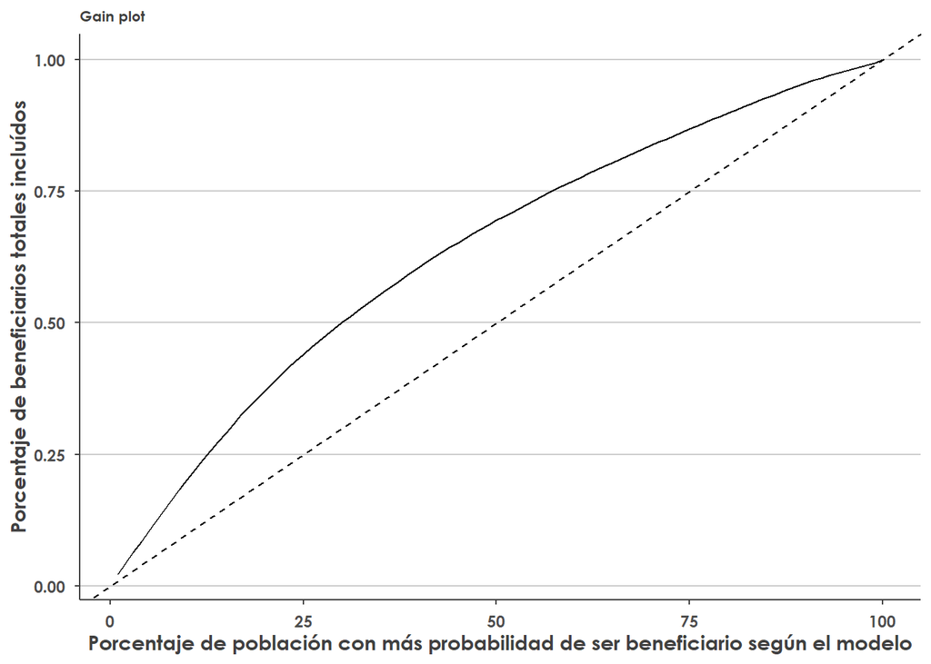

```r
dfmodelo_order <- dfmodelo[order(-prob_pred)]

dfmodelo_order[, cum_pop := seq_len(.N)/.N]
dfmodelo_order[, cum_events := cumsum(benef)/sum(benef)]
dfmodelo_order[, lift := cum_events / cum_pop]
dfmodelo_order[, pct:=ntile(-prob_pred, 100)]

dfmodelo_order <- dfmodelo_order[
  , .(
    pop_share = .N / nrow(dfmodelo_order),
    event_share = sum(benef) / sum(dfmodelo_order$benef)
  ),
  by=pct
][order(pct)]

dfmodelo_order[, cum_pop := cumsum(pop_share)]
dfmodelo_order[, cum_events := cumsum(event_share)]

dfmodelo_order[, lift := cum_events / cum_pop]

# Gain plot
p2<-
dfmodelo_order %>%
  ggplot(aes(cum_pop*100, cum_events)) +
  geom_line() +
  geom_abline(slope=0.01, intercept=0, linetype="dashed")+
  ggtitle("Gain plot")+
  theme(axis.title=element_text())+
  labs(x="Porcentaje de población con más probabilidad de ser beneficiario según el modelo",
       y="Porcentaje de beneficiarios totales incluídos")

p2
```

### Lift

Es otra versión de la curva Gain. En este caso, se muestra el valor correspondiente de dividir el eje de ordenadas entre el eje de abscisas en el Gain plot. Ejemplo de lectura para valor abscisa=25 y ordenada= 1.75: “El 25% de la población con más probabilidad de ser beneficiaria incluye 1.75 veces más (43.75%) de la población beneficiaria”.

**Mostrar código**

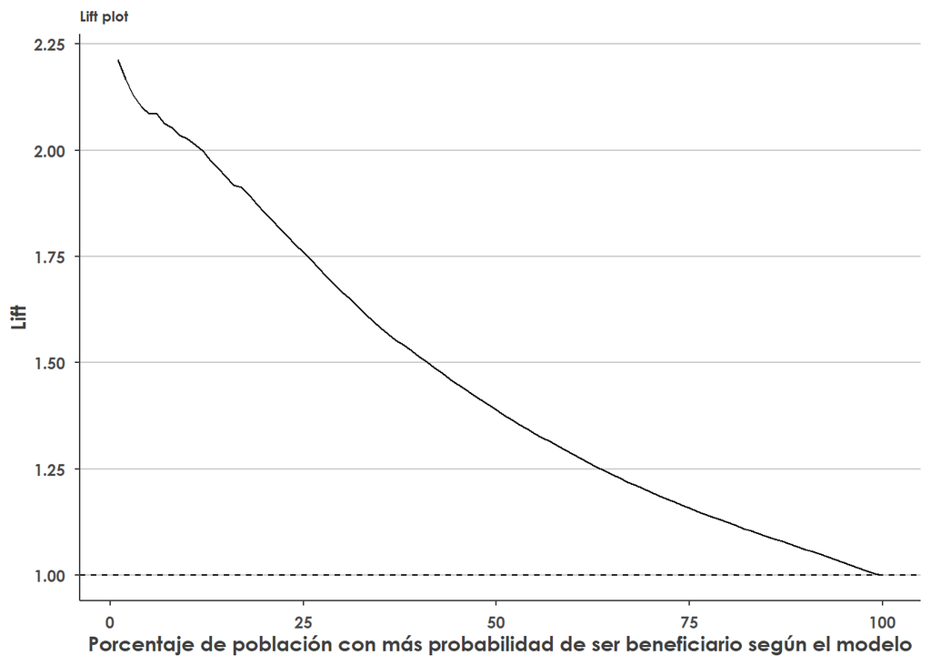

```r
# Lift

p3<-
dfmodelo_order %>%
  ggplot(aes(cum_pop*100, lift)) +
  geom_line() +
  geom_hline(yintercept=1, linetype="dashed")+
  ggtitle("Lift plot")+
  theme(axis.title = element_text())+
  labs(y="Lift",
       x="Porcentaje de población con más probabilidad de ser beneficiario según el modelo")

p3
```

## Classification metrics

Una vez mostradas las gráficas anteriores, podemos proceder a elegir un umbral que maximice la capacidad predictiva del modelo.

En este caso, usamos una función que elige un umbral que maximiza la True Positive Rate y la True Negative Rate, es decir, los aciertos del modelo. Este umbral se coloca en el 0.447, bastante cercano a la ratio de beneficiarios real. Esto significa que consideramos como positivos aquellas observaciones cuya probabilidad predicha supera este 0.447.

Una vez hecho esto, podemos mostrar la matriz de confusión y otras métricas de acuerdo al umbral.

**Mostrar código**

```r
dfmodelo[, pred := fifelse(prob_pred > best_thr, 1, 0)]

conf_matrix <- table(
  Real=dfmodelo$benef,
  Pred=dfmodelo$pred
)

print(conf_matrix)
```

```
    Pred
Real      0      1
   0 435115 147656
   1 156770 232193
```

**Mostrar código**

```r
TP <- conf_matrix["1","1"]
FP <- conf_matrix["0","1"]
FN <- conf_matrix["1","0"]
TN <- conf_matrix["0","0"]

precision <- TP/(TP+FP)
recall <- TP/(TP+FN)
specificity <- TN/(TN+FP)
f1 <- 2*(precision*recall)/(precision+recall)

cat("\nPrecision:",round(precision,4),
    "\nRecall:",round(recall,4),
    "\nSpecificity:",round(specificity,4),
    "\nF1:",round(f1,4),
    "\nAUC:", round(auc_val, 4))
```

```
Precision: 0.6113
Recall: 0.597
Specificity: 0.7466
F1: 0.604
AUC: 0.7246
```